# Linear and Regression Model of Movies Data

# Setting working directory and load the movies data set

```r
setwd("C:/Users/ddddd/Regression/_movies")
```

```r
moviesdata <- load("C:/Users/ddddd/Regression/_movies/_movies.R")
```

# Installing packages and loading the libraries

```r
library(devtools)
devtools::install_github("statswithr/statsr")
```

```r
library(ggplot2)
library(dplyr)
library(statsr)
library(corrplot)
library(gridExtra)
library(grid)
```

# About the Data

Dataset has the collection from IMDB and Rotten Tomatoes websites. Here we are asked to analyse this data so we can find that what thing makes a movie popular? whether it’s name , it’s cast, it’s director, it’s genre ,i.e. whether it is a comedy movie, fictional, romantic, horror, etc.

Both websites are working for the same thing but having different methods.

Rotten Tomatoes is a reviewer website. It gives the reviews based on their critic reviews and popularity in fans and news rarrings etc. It is basically working for the tomatometer rating which breaks it’s review criteria into different zones for example Rotten reviews which have lower ratings , certified fresh reviews have higher rattings and the fresh reviews have the rattings between these two. So by this kind of information one can easily determine and go for a movie or show which is worth watching.

IDMB is also doing the similar things but it also includes some other imformations. It includes the movie rattings, shows and provides the critic reviews and upcoming best movies.

# Part 2: Research question

There are various movies which are more popular than others so we are asked to find out this thing. So, I would like to do research about Rotten tomatoes website’s working.So the research question is:

Which elements give the most impact on the popularity of a movie on this website?

Here, I am taking few varibles for this research: genre , critics_score, critics_rating, audience_score, audience_rating, best_dir_win, best_actress_win, best_actor_win, mpaa_rating, runtime etc.

# Part 3: Exploratory data analysis

Now, we will see the summary and plot the graph of each variables behavior or the clear view of representing the data. For this first I remove the varibles which are not usable to find the research or we can say the varibles should be excluded and for this purpose we first clean thias data set by removing those varibles.

Removing the varibles which are not in use for research purpose

```r
moviesdata$title<-NULL
moviesdata$best_pic_nom<-NULL
moviesdata$thtr_rel_year<-NULL
moviesdata$title_type<-NULL
moviesdata$studioimdb_rating<-NULL
moviesdata$dvd_rel_year<-NULL
moviesdata$dvd_rel_month<-NULL
moviesdata$dvd_rel_day<-NULL
moviesdata$imdb_num_votes<-NULL
moviesdata$best_pic_win<-NULL
moviesdata$top200_box<-NULL
moviesdata$actor1<-NULL
moviesdata$actor2<-NULL
moviesdata$actor3<-NULL
moviesdata$actor4<-NULL
moviesdata$actor5<-NULL
moviesdata$imdb_url<-NULL
moviesdata$rt_url<-NULL
moviesdata$director<-NULL
moviesdata$dvd_rel_year<-NULL
moviesdata$dvd_rel_month<-NULL
moviesdata$dvd_rel_day<-NULL
str(movies)
```

```
## Classes 'tbl_df', 'tbl' and 'data.frame':    651 obs. of  32 variables:
##  $ title           : chr  "Filly Brown" "The Dish" "Waiting for Guffman" "The Age of Innocence" ...
##  $ title_type      : Factor w/ 3 levels "Documentary",..: 2 2 2 2 2 1 2 2 1 2 ...
##  $ genre           : Factor w/ 11 levels "Action & Adventure",..: 6 6 4 6 7 5 6 6 5 6 ...
##  $ runtime         : num  80 101 84 139 90 78 142 93 88 119 ...
##  $ mpaa_rating     : Factor w/ 6 levels "G","NC-17","PG",..: 5 4 5 3 5 6 4 5 6 6 ...
##  $ studio          : Factor w/ 211 levels "20th Century Fox",..: 91 202 167 34 13 163 147 118 88 84 ...
##  $ thtr_rel_year   : num  2013 2001 1996 1993 2004 ...
##  $ thtr_rel_month  : num  4 3 8 10 9 1 1 11 9 3 ...
##  $ thtr_rel_day    : num  19 14 21 1 10 15 1 8 7 2 ...
##  $ dvd_rel_year    : num  2013 2001 2001 2001 2005 ...
##  $ dvd_rel_month   : num  7 8 8 11 4 4 2 3 1 8 ...
##  $ dvd_rel_day     : num  30 28 21 6 19 20 18 2 21 14 ...
##  $ imdb_rating     : num  5.5 7.3 7.6 7.2 5.1 7.8 7.2 5.5 7.5 6.6 ...
##  $ imdb_num_votes  : int  899 12285 22381 35096 2386 333 5016 2272 880 12496 ...
```

[output cut: 18 more lines]

Now start plotting the graphs.

1.Plot of genres of movies

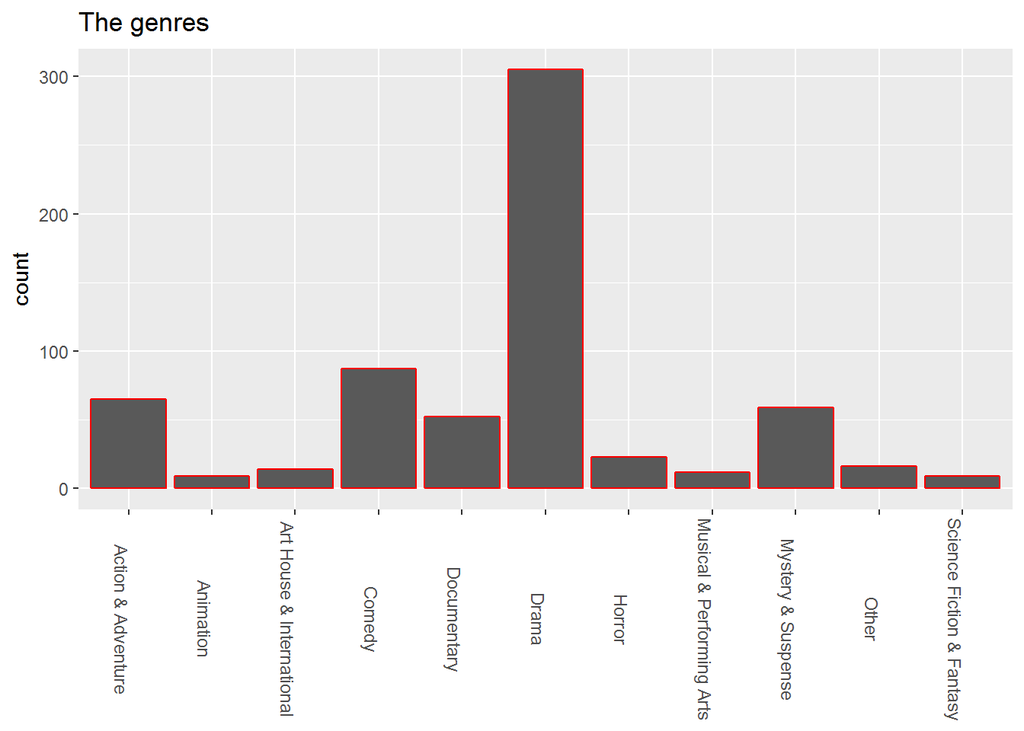

```r
library(ggplot2)
ggplot(data=movies , aes(x=genre) ) + geom_bar(color = "red") + ggtitle("The genres") + theme(axis.title.x=element_blank()) + theme(axis.text.x = element_text(angle=270))
```

By this plot we observe the highest genre is Drama.

Plot of ratings of critics

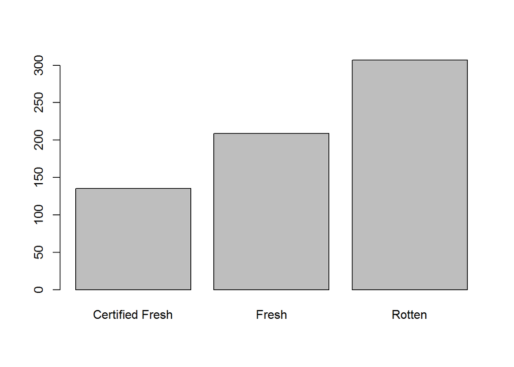

```r
plot(movies$critics_rating)
```

This plot tells the three types ratings of rotten tomatoes website.

Plot of score of critics

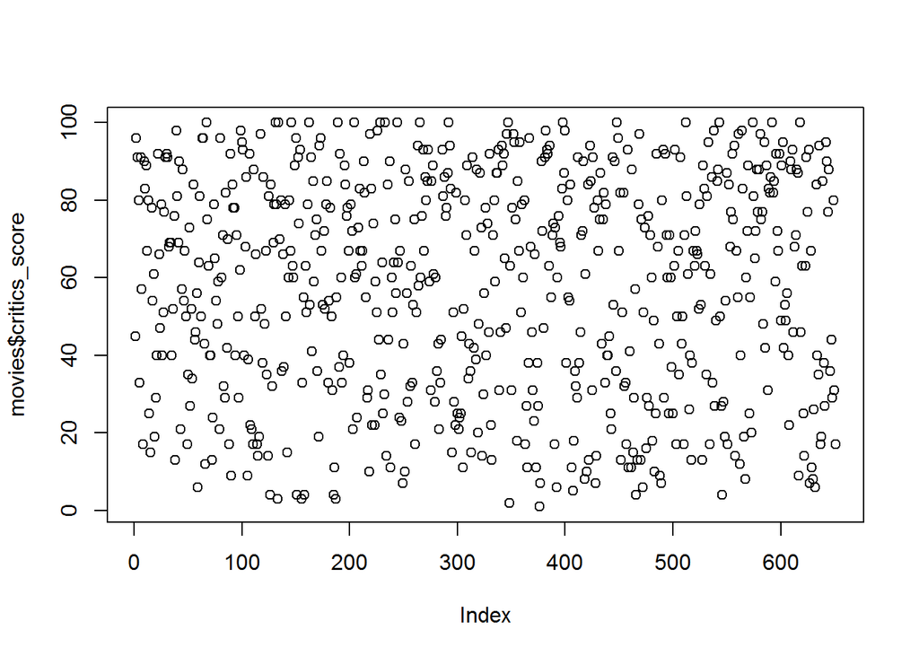

```r
plot(movies$critics_score)
```

Plot of ratings of audience

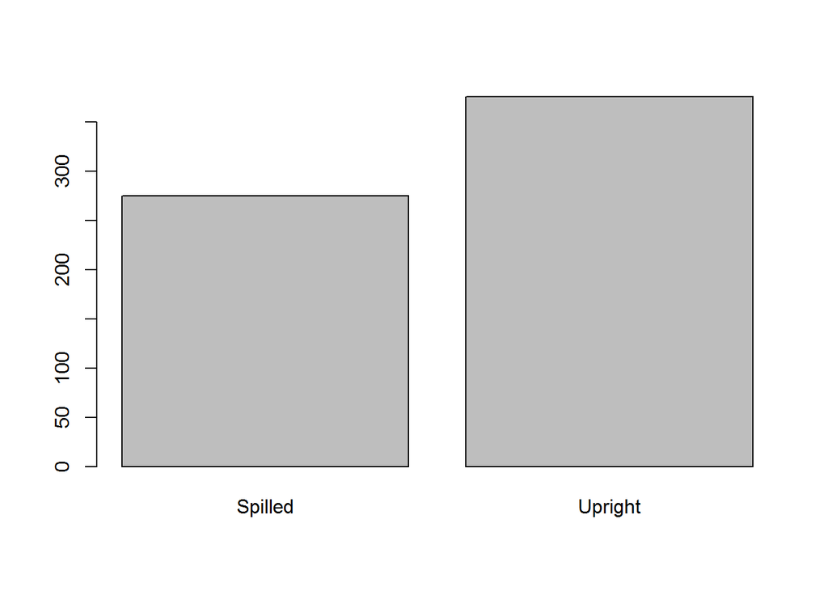

```r
plot(movies$audience_rating)
```

This graph tells the audience ratings which is either upright or spilled.

Plot of score of audience

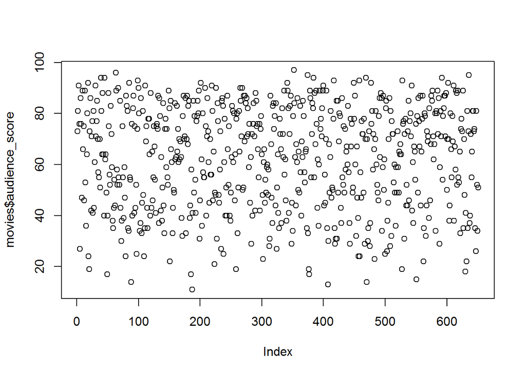

```r
plot(movies$audience_score)
```

Plot of ratings of MPAA

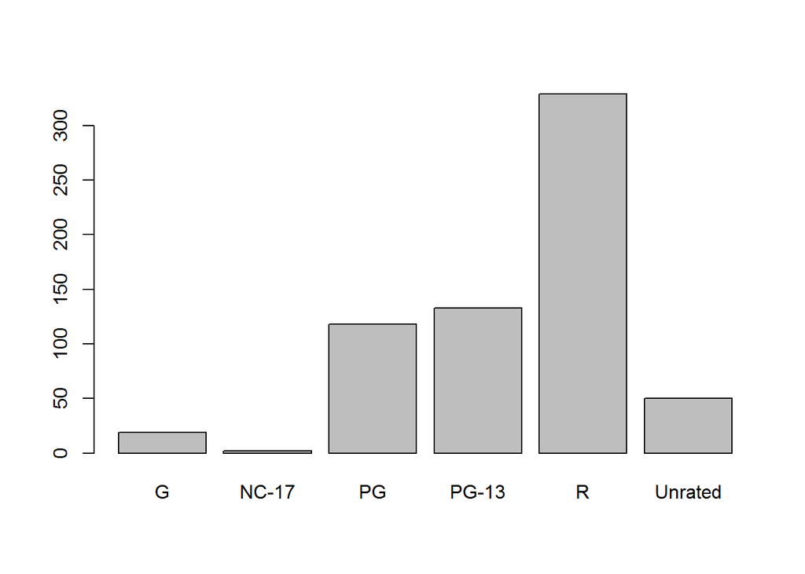

```r
plot(movies$mpaa_rating)
```

Plot of runtime of movie

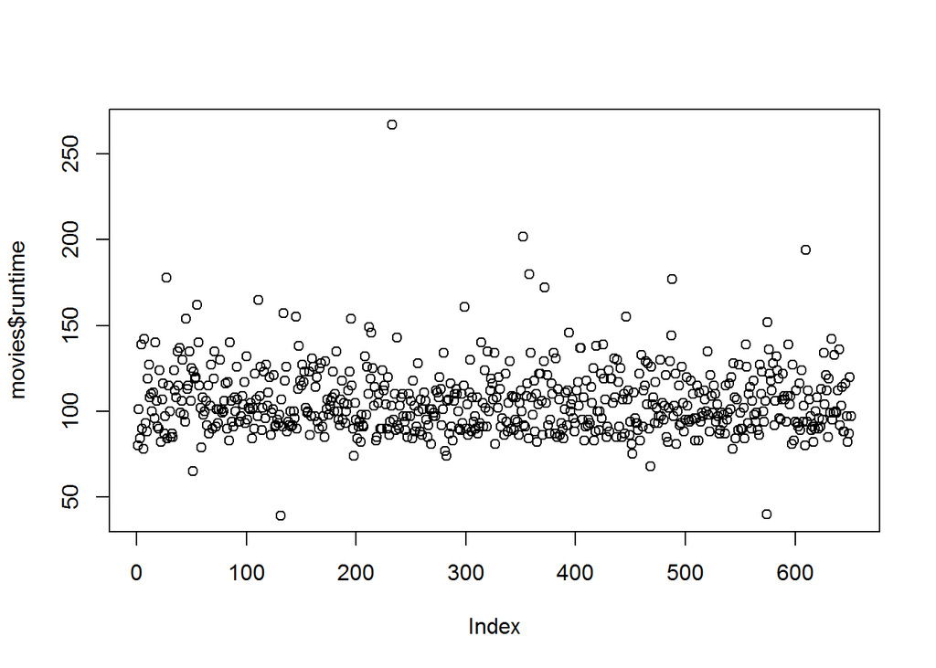

```r
plot(movies$runtime)
```

Plot of best director win the award

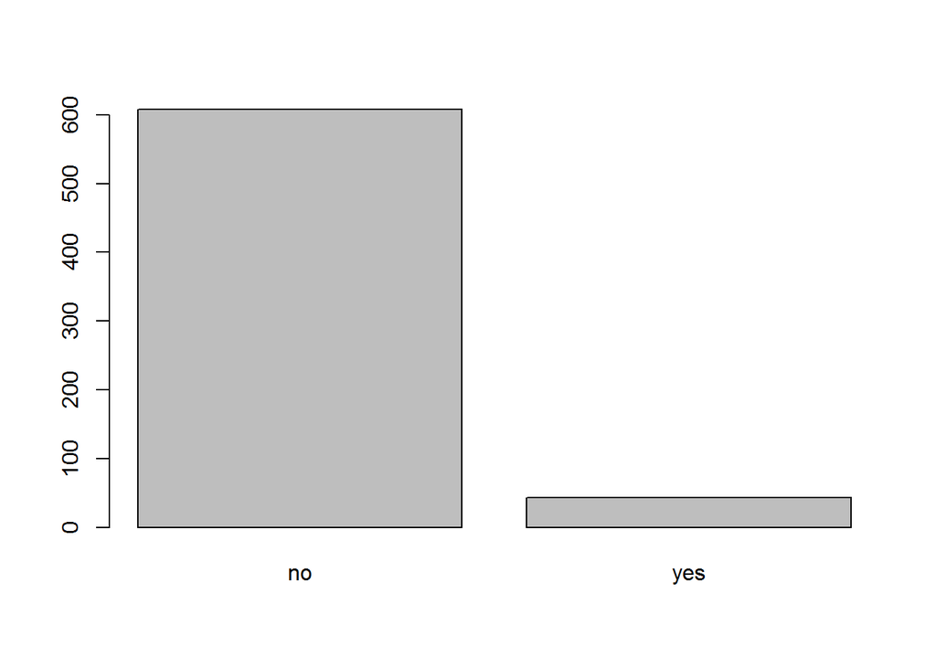

```r
plot(movies$best_dir_win)
```

Plot of best actor win the award

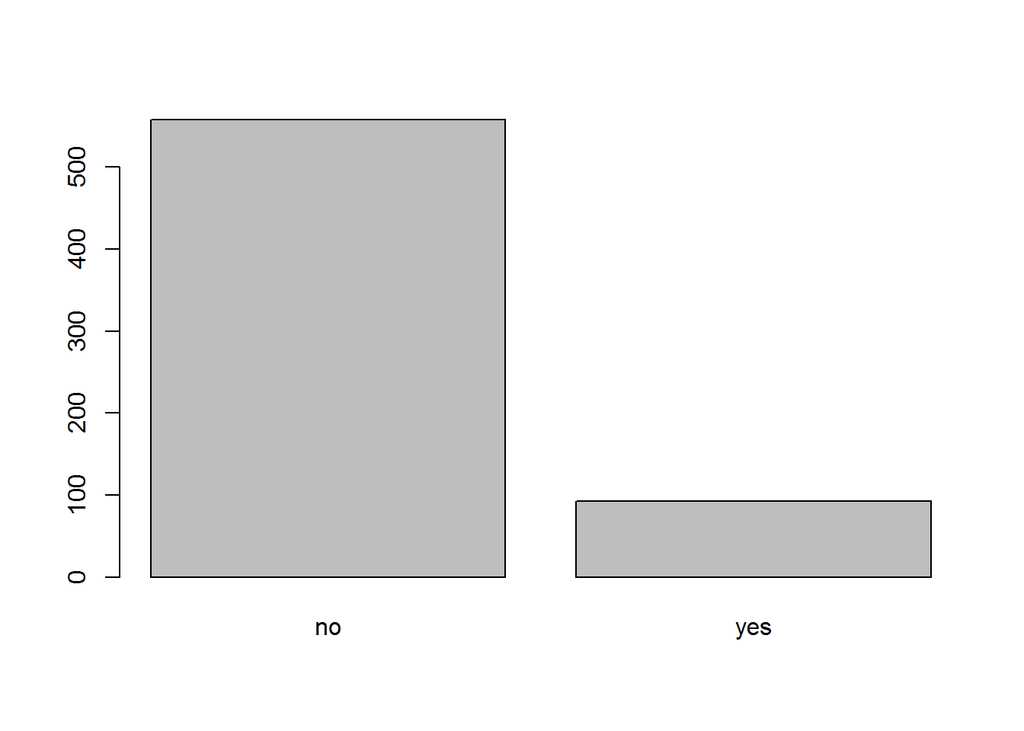

```r
plot(movies$best_actor_win)
```

Plot of best actress win the award

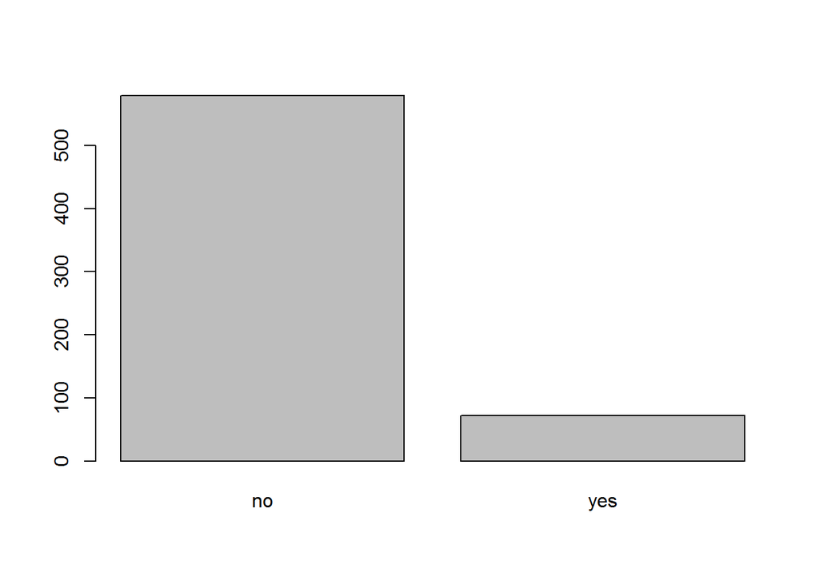

```r
plot(movies$best_actress_win)
```

After this EDA(Exploratory data analysis) , we see some facts of varibles used but the thing which impact the most ,i.e. for a movie rating which varibles are most essential , can’t explained . so move on to the regression model which gives the best results to be predicted.

# Part 4 Modelling

```r
my_model_1 = lm( critics_score ~ genre + audience_score + runtime + mpaa_rating + best_actor_win + best_actress_win + best_dir_win  , data = movies)
summary(my_model_1)
```

```
##
## Call:
## lm(formula = critics_score ~ genre + audience_score + runtime +
##     mpaa_rating + best_actor_win + best_actress_win + best_dir_win,
##     data = movies)
##
## Residuals:
##     Min      1Q  Median      3Q     Max
## -60.672 -13.125   1.842  14.101  50.053
##
## Coefficients:
##                                 Estimate Std. Error t value Pr(>|t|)
## (Intercept)                     -0.04525    7.04947  -0.006 0.994880
## genreAnimation                  -4.78674    7.57186  -0.632 0.527503
## genreArt House & International  -0.64172    5.86868  -0.109 0.912962
## genreComedy                      1.90202    3.23782   0.587 0.557121
## genreDocumentary                14.52471    4.38894   3.309 0.000988 ***
## genreDrama                      10.13705    2.79319   3.629 0.000307 ***
## genreHorror                      9.21518    4.84200   1.903 0.057474 .
## genreMusical & Performing Arts  10.42039    6.23919   1.670 0.095387 .
## genreMystery & Suspense         10.92235    3.61634   3.020 0.002628 **
## genreOther                      10.97696    5.47413   2.005 0.045365 *
## genreScience Fiction & Fantasy   9.88282    6.90969   1.430 0.153132
## audience_score                   0.85884    0.04324  19.864  < 2e-16 ***
## runtime                          0.04423    0.04570   0.968 0.333486
## mpaa_ratingNC-17                13.41119   14.71416   0.911 0.362409
## mpaa_ratingPG                   -8.60914    5.34083  -1.612 0.107475
## mpaa_ratingPG-13               -14.37010    5.47551  -2.624 0.008890 **
## mpaa_ratingR                    -9.97495    5.29058  -1.885 0.059834 .
## mpaa_ratingUnrated              -0.05602    6.06020  -0.009 0.992628
## best_actor_winyes                1.07550    2.29570   0.468 0.639599
## best_actress_winyes              2.85205    2.52700   1.129 0.259484
## best_dir_winyes                  8.00555    3.18927   2.510 0.012318 *
## ---
## Signif. codes:  0 '***' 0.001 '**' 0.01 '*' 0.05 '.' 0.1 ' ' 1
##
## Residual standard error: 19.38 on 629 degrees of freedom
##   (1 observation deleted due to missingness)
## Multiple R-squared:  0.549,  Adjusted R-squared:  0.5346
## F-statistic: 38.28 on 20 and 629 DF,  p-value: < 2.2e-16
```

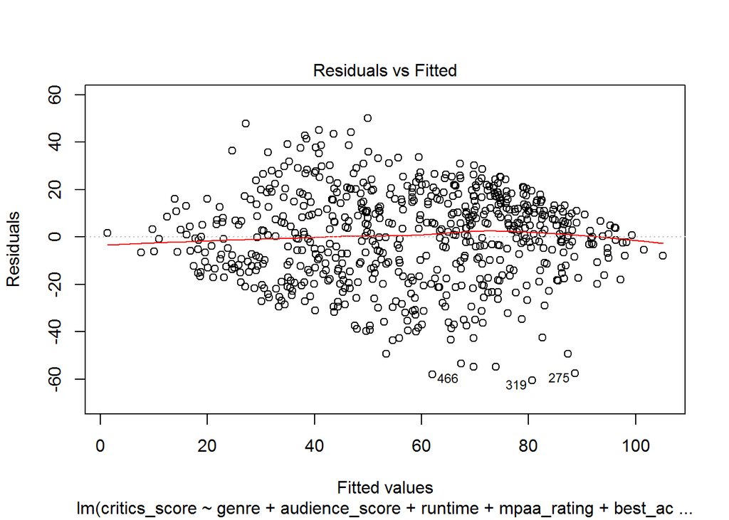

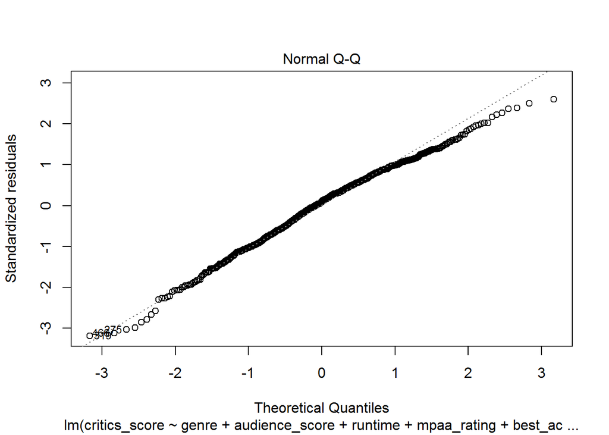

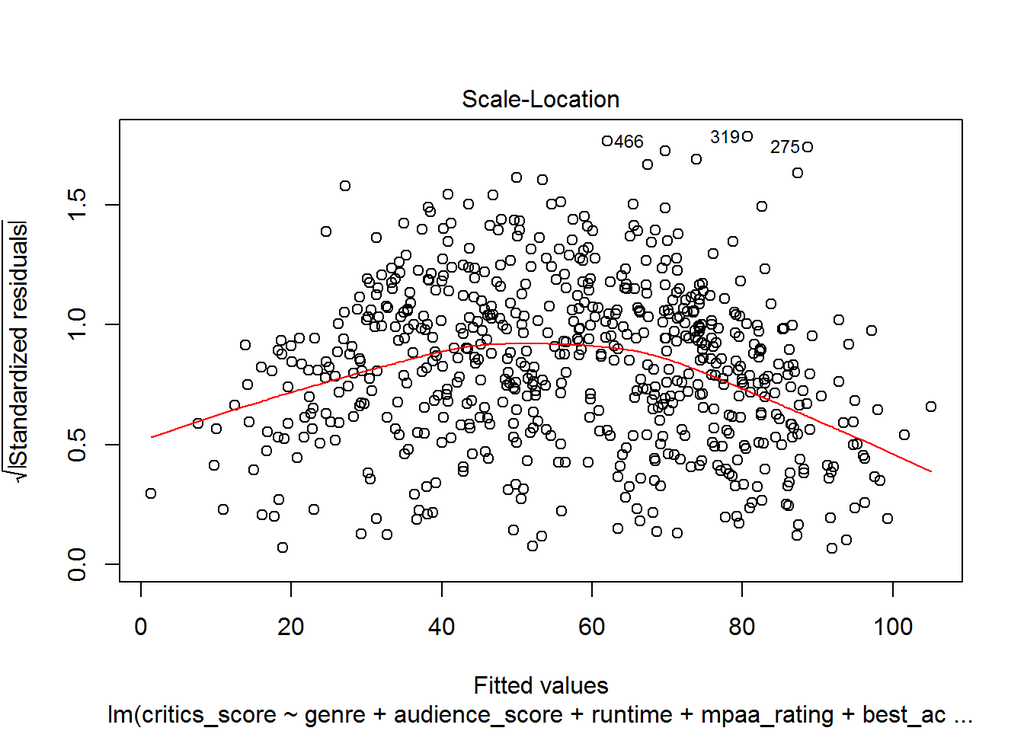

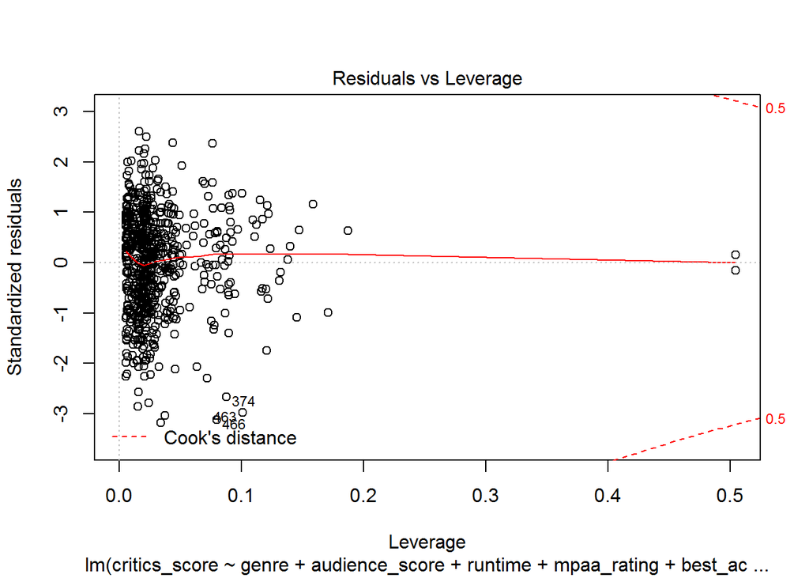

```r
plot(my_model_1)
```

Excluding runtime

```r
my_model_2 = lm( critics_score ~ genre + audience_score + mpaa_rating + best_actor_win + best_actress_win + best_dir_win  , data = movies)
summary(my_model_2)
```

```
##
## Call:
## lm(formula = critics_score ~ genre + audience_score + mpaa_rating +
##     best_actor_win + best_actress_win + best_dir_win, data = movies)
##
## Residuals:
##     Min      1Q  Median      3Q     Max
## -60.802 -12.907   2.065  14.030  49.978
##
## Coefficients:
##                                 Estimate Std. Error t value Pr(>|t|)
## (Intercept)                      3.60588    5.94952   0.606  0.54468
## genreAnimation                  -5.23492    7.55131  -0.693  0.48841
## genreArt House & International  -0.79714    5.86105  -0.136  0.89186
## genreComedy                      1.52622    3.21173   0.475  0.63481
## genreDocumentary                13.95637    4.33970   3.216  0.00137 **
## genreDrama                      10.21927    2.78955   3.663  0.00027 ***
## genreHorror                      8.80000    4.81863   1.826  0.06829 .
## genreMusical & Performing Arts  10.63920    6.22983   1.708  0.08817 .
## genreMystery & Suspense         10.99697    3.61247   3.044  0.00243 **
## genreOther                      11.12750    5.46731   2.035  0.04224 *
## genreScience Fiction & Fantasy   9.85156    6.90379   1.427  0.15408
## audience_score                   0.86586    0.04258  20.336  < 2e-16 ***
## mpaa_ratingNC-17                13.42780   14.70169   0.913  0.36141
## mpaa_ratingPG                   -8.22866    5.32172  -1.546  0.12255
## mpaa_ratingPG-13               -13.64626    5.41941  -2.518  0.01205 *
## mpaa_ratingR                    -9.49213    5.26231  -1.804  0.07174 .
## mpaa_ratingUnrated               0.61910    6.00596   0.103  0.91793
## best_actor_winyes                1.53031    2.24522   0.682  0.49575
## best_actress_winyes              3.20563    2.49835   1.283  0.19993
## best_dir_winyes                  8.62149    3.12234   2.761  0.00593 **
## ---
## Signif. codes:  0 '***' 0.001 '**' 0.01 '*' 0.05 '.' 0.1 ' ' 1
##
## Residual standard error: 19.37 on 631 degrees of freedom
## Multiple R-squared:  0.5487, Adjusted R-squared:  0.5351
## F-statistic: 40.38 on 19 and 631 DF,  p-value: < 2.2e-16
```

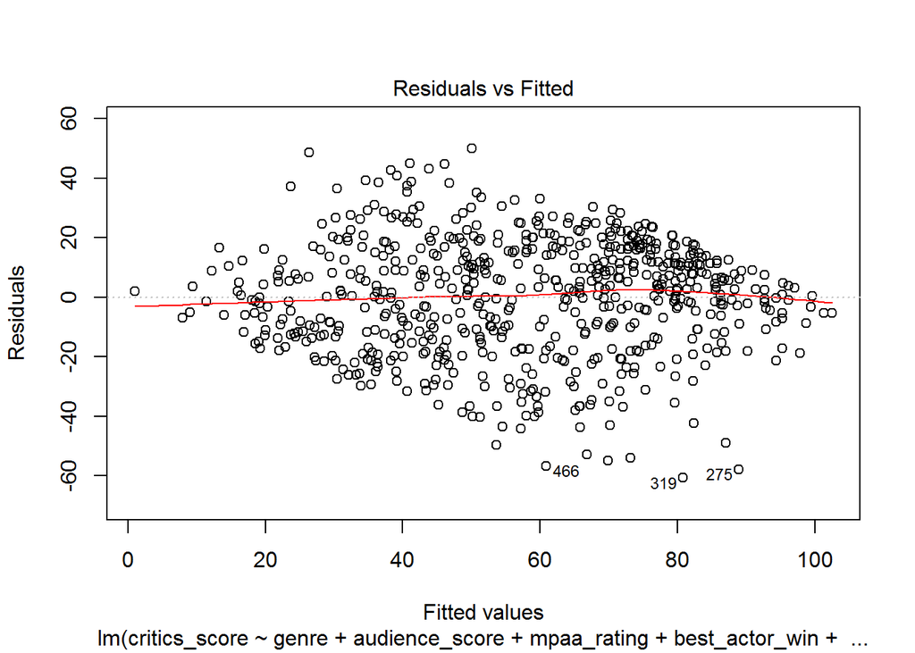

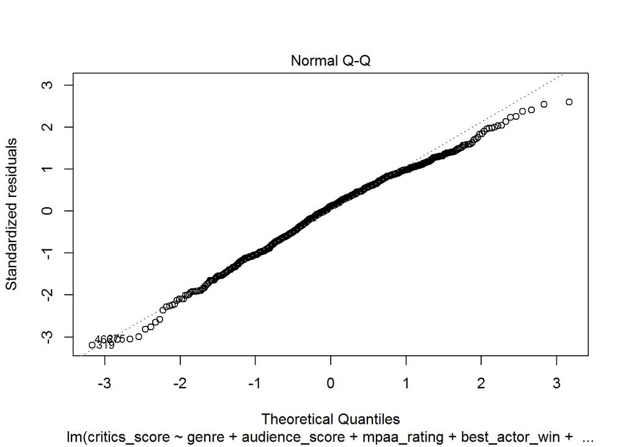

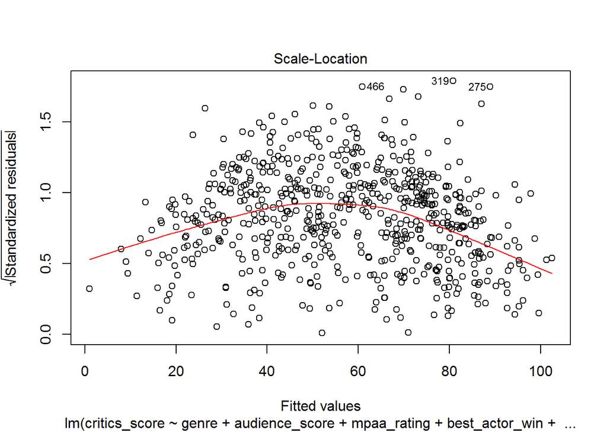

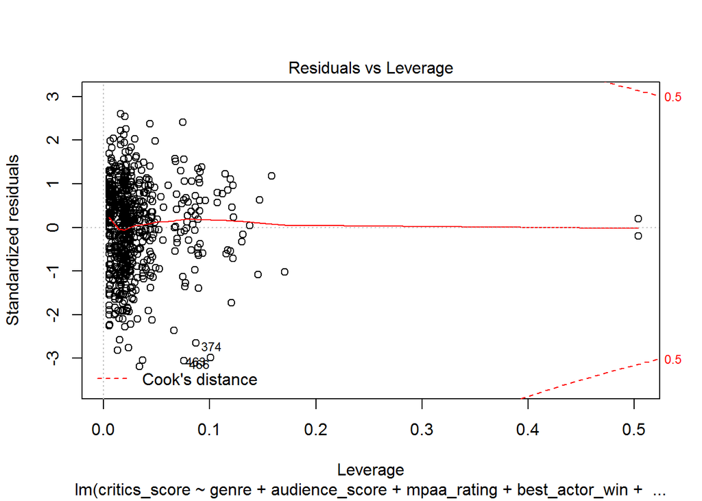

```r
plot(my_model_2)
```

Excluding mpaa_rating

```r
my_model_2 = lm( critics_score ~ genre + audience_score  + best_actor_win + best_actress_win + best_dir_win  , data = movies)
summary(my_model_2)
```

```
##
## Call:
## lm(formula = critics_score ~ genre + audience_score + best_actor_win +
##     best_actress_win + best_dir_win, data = movies)
##
## Residuals:
##     Min      1Q  Median      3Q     Max
## -67.349 -13.205   2.321  13.996  51.309
##
## Coefficients:
##                                Estimate Std. Error t value Pr(>|t|)
## (Intercept)                    -7.00748    3.33661  -2.100 0.036106 *
## genreAnimation                  1.28884    6.98535   0.185 0.853675
## genreArt House & International  1.59645    5.80043   0.275 0.783230
## genreComedy                     0.49226    3.22303   0.153 0.878658
## genreDocumentary               19.72801    3.86318   5.107 4.34e-07 ***
## genreDrama                      9.81710    2.74913   3.571 0.000382 ***
## genreHorror                     9.89863    4.76954   2.075 0.038352 *
## genreMusical & Performing Arts 11.65608    6.25490   1.864 0.062851 .
## genreMystery & Suspense        10.55507    3.56317   2.962 0.003168 **
## genreOther                     11.51734    5.50373   2.093 0.036777 *
## genreScience Fiction & Fantasy 10.89645    6.97362   1.563 0.118662
## audience_score                  0.88843    0.04263  20.838  < 2e-16 ***
## best_actor_winyes               1.44884    2.26060   0.641 0.521812
## best_actress_winyes             2.72136    2.51958   1.080 0.280514
## best_dir_winyes                 8.09840    3.15193   2.569 0.010416 *
## ---
## Signif. codes:  0 '***' 0.001 '**' 0.01 '*' 0.05 '.' 0.1 ' ' 1
##
## Residual standard error: 19.59 on 636 degrees of freedom
## Multiple R-squared:  0.5348, Adjusted R-squared:  0.5245
## F-statistic: 52.22 on 14 and 636 DF,  p-value: < 2.2e-16
```

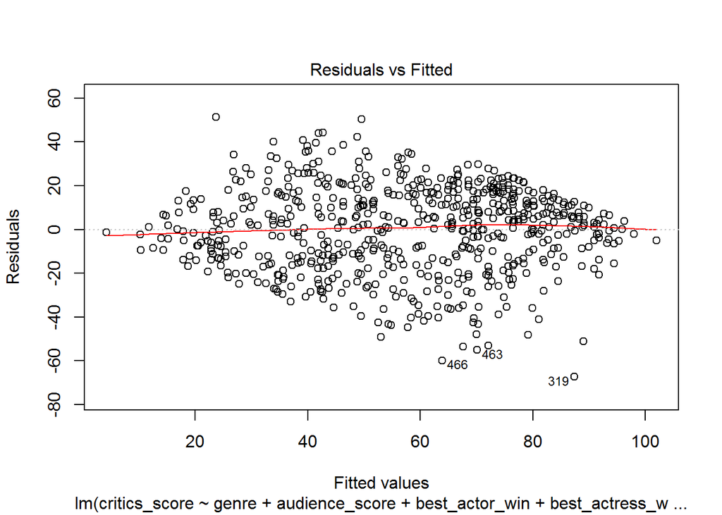

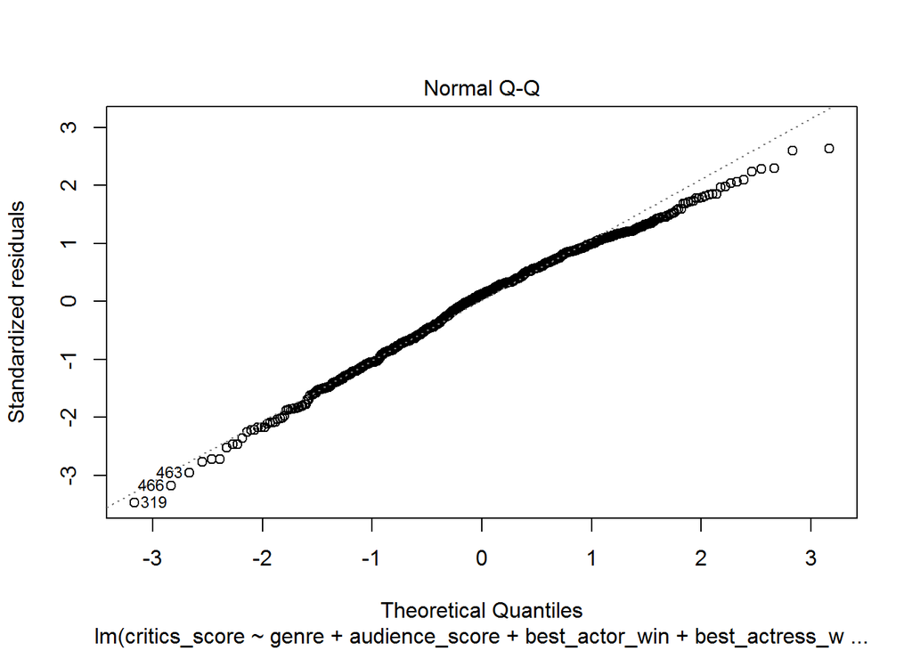

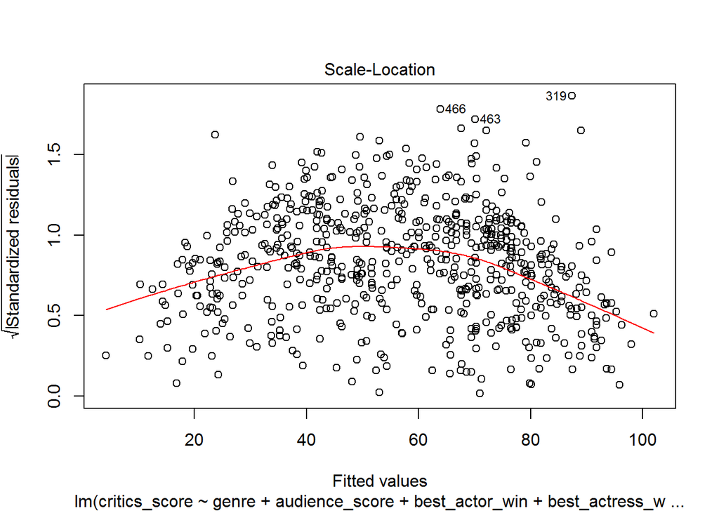

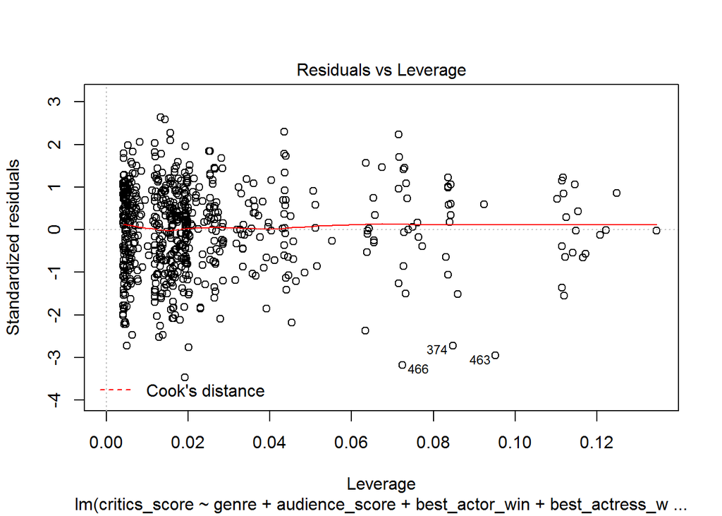

```r
plot(my_model_2)
```

Excluding best_actor_win

```r
my_model_3 = lm( critics_score ~ genre + audience_score  + best_actress_win + best_dir_win  , data = movies)
summary(my_model_3)
```

```
##
## Call:
## lm(formula = critics_score ~ genre + audience_score + best_actress_win +
##     best_dir_win, data = movies)
##
## Residuals:
##     Min      1Q  Median      3Q     Max
## -67.402 -13.340   2.395  13.974  51.662
##
## Coefficients:
##                                Estimate Std. Error t value Pr(>|t|)
## (Intercept)                    -6.87603    3.32876  -2.066  0.03927 *
## genreAnimation                  1.28312    6.98211   0.184  0.85425
## genreArt House & International  1.43576    5.79233   0.248  0.80431
## genreComedy                     0.45548    3.22103   0.141  0.88759
## genreDocumentary               19.62635    3.85814   5.087 4.79e-07 ***
## genreDrama                      9.89035    2.74549   3.602  0.00034 ***
## genreHorror                     9.74766    4.76151   2.047  0.04105 *
## genreMusical & Performing Arts 11.61006    6.25159   1.857  0.06375 .
## genreMystery & Suspense        10.75745    3.54751   3.032  0.00252 **
## genreOther                     11.60896    5.49933   2.111  0.03516 *
## genreScience Fiction & Fantasy 10.73336    6.96575   1.541  0.12384
## audience_score                  0.88871    0.04261  20.855  < 2e-16 ***
## best_actress_winyes             2.88377    2.50564   1.151  0.25020
## best_dir_winyes                 8.25696    3.14075   2.629  0.00877 **
## ---
## Signif. codes:  0 '***' 0.001 '**' 0.01 '*' 0.05 '.' 0.1 ' ' 1
##
## Residual standard error: 19.58 on 637 degrees of freedom
## Multiple R-squared:  0.5345, Adjusted R-squared:  0.525
## F-statistic: 56.25 on 13 and 637 DF,  p-value: < 2.2e-16
```

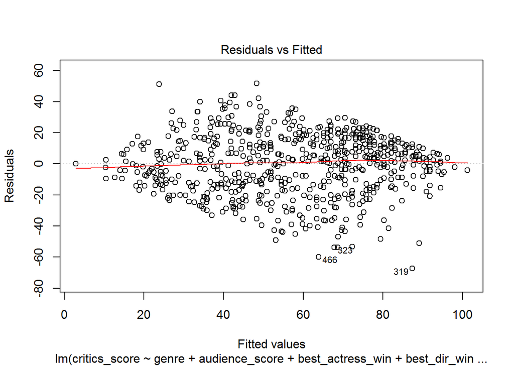

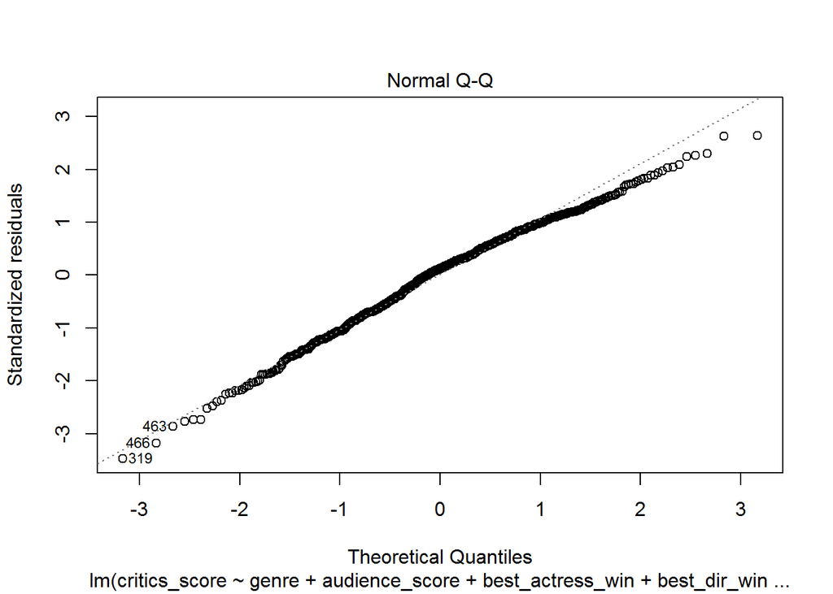

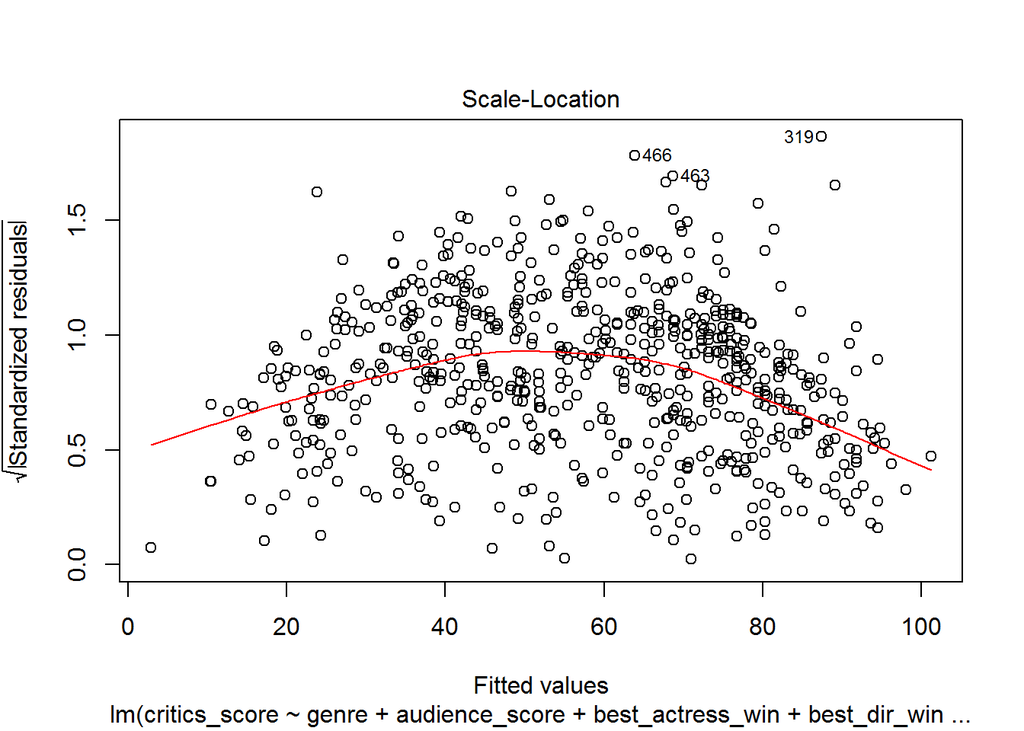

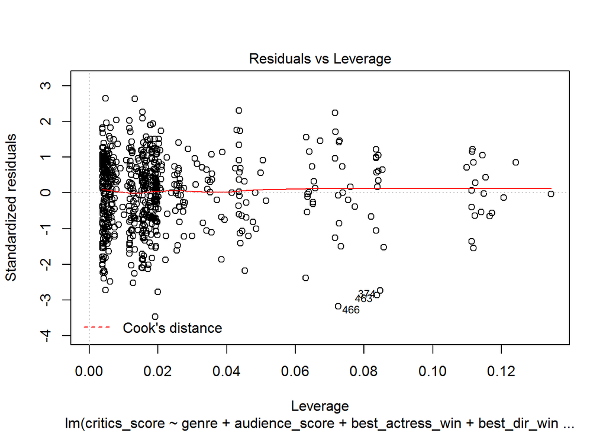

```r
plot(my_model_3)
```

Excluding best_actress_win

```r
my_model_4 = lm( critics_score ~ genre + audience_score   + best_dir_win  , data = movies)
summary(my_model_4)
```

```
##
## Call:
## lm(formula = critics_score ~ genre + audience_score + best_dir_win,
##     data = movies)
##
## Residuals:
##     Min      1Q  Median      3Q     Max
## -67.458 -13.526   2.345  13.795  51.239
##
## Coefficients:
##                                Estimate Std. Error t value Pr(>|t|)
## (Intercept)                    -6.93293    3.32924  -2.082 0.037700 *
## genreAnimation                  1.61214    6.97803   0.231 0.817365
## genreArt House & International  1.64914    5.79084   0.285 0.775901
## genreComedy                     0.75866    3.21106   0.236 0.813304
## genreDocumentary               19.67471    3.85889   5.099 4.52e-07 ***
## genreDrama                     10.33017    2.71945   3.799 0.000159 ***
## genreHorror                     9.75831    4.76271   2.049 0.040881 *
## genreMusical & Performing Arts 11.58424    6.25314   1.853 0.064409 .
## genreMystery & Suspense        11.23457    3.52410   3.188 0.001503 **
## genreOther                     11.95921    5.49230   2.177 0.029813 *
## genreScience Fiction & Fantasy 10.72327    6.96752   1.539 0.124291
## audience_score                  0.88948    0.04262  20.871  < 2e-16 ***
## best_dir_winyes                 8.50564    3.13411   2.714 0.006829 **
## ---
## Signif. codes:  0 '***' 0.001 '**' 0.01 '*' 0.05 '.' 0.1 ' ' 1
##
## Residual standard error: 19.58 on 638 degrees of freedom
## Multiple R-squared:  0.5335, Adjusted R-squared:  0.5247
## F-statistic:  60.8 on 12 and 638 DF,  p-value: < 2.2e-16
```

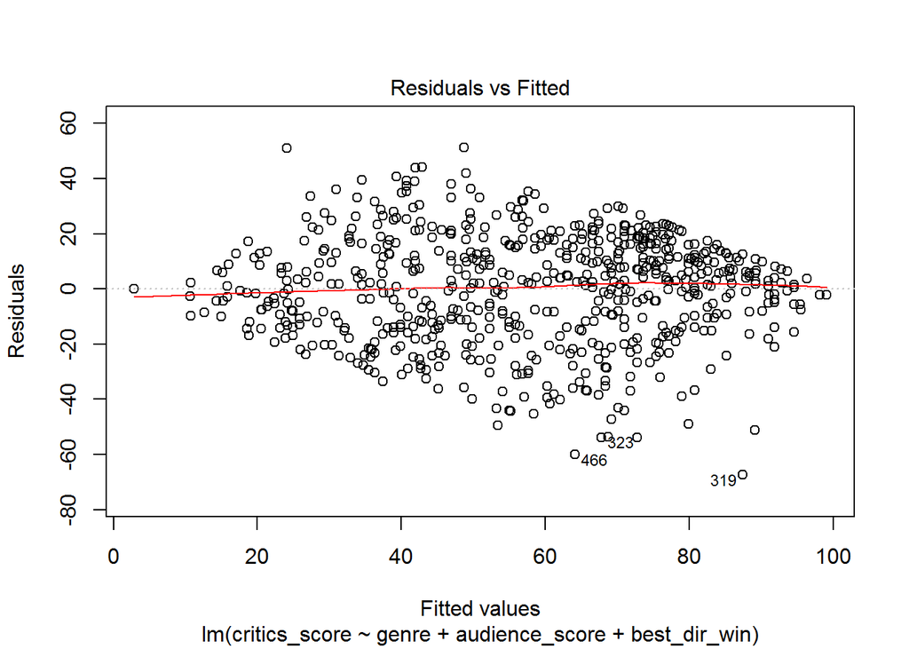

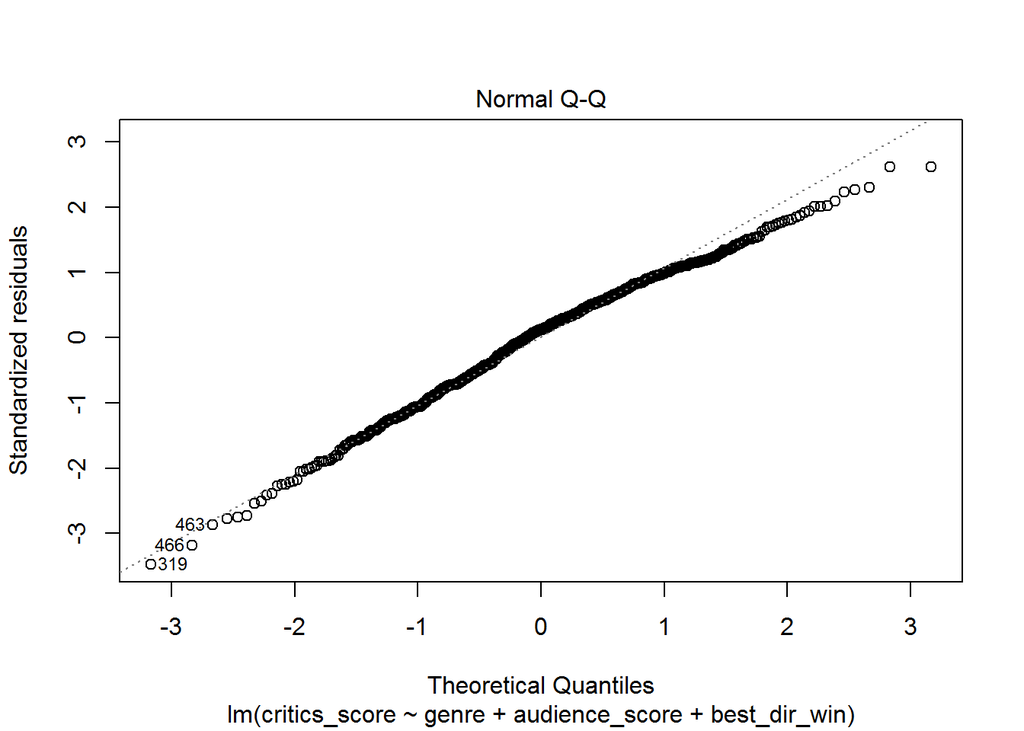

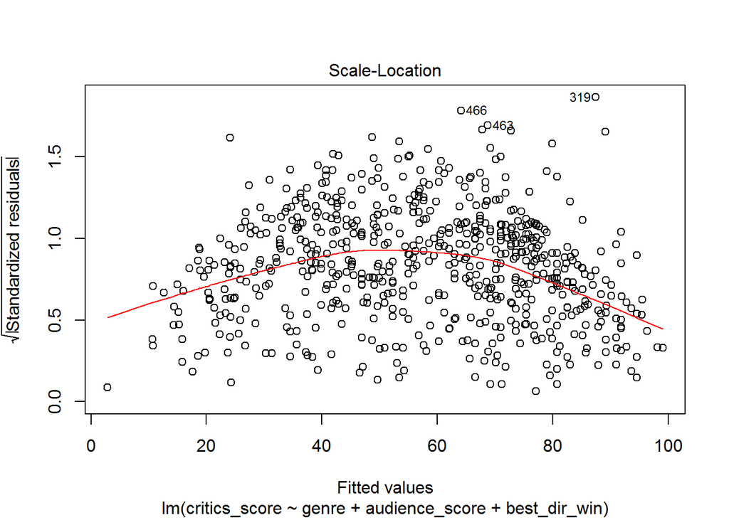

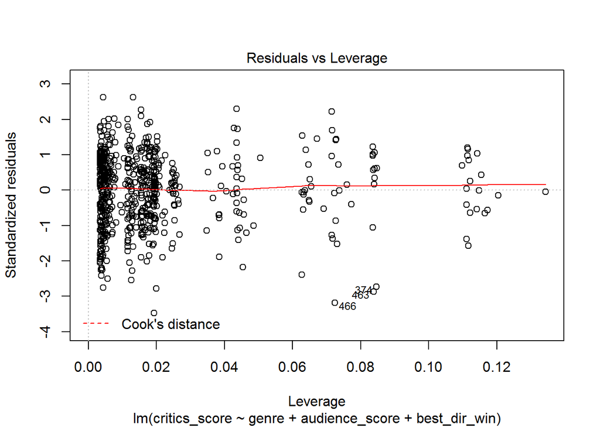

```r
plot(my_model_4)
```

Finally , we exclude the variable best_dir_win for getting the final regression model,i.e. my_model_regre which only includes varibles critics_score, genre of movies and audience_score

```r
my_model_regre = lm( critics_score ~ genre + audience_score , data = movies)
summary(my_model_regre)
```

```
##
## Call:
## lm(formula = critics_score ~ genre + audience_score, data = movies)
##
## Residuals:
##     Min      1Q  Median      3Q     Max
## -67.475 -13.550   2.611  14.415  50.799
##
## Coefficients:
##                                Estimate Std. Error t value Pr(>|t|)
## (Intercept)                    -7.15886    3.34473  -2.140 0.032705 *
## genreAnimation                  0.96807    7.00864   0.138 0.890186
## genreArt House & International  0.98339    5.81438   0.169 0.865747
## genreComedy                     0.64412    3.22673   0.200 0.841843
## genreDocumentary               18.74773    3.86284   4.853 1.53e-06 ***
## genreDrama                     10.34282    2.73296   3.784 0.000169 ***
## genreHorror                     9.71558    4.78635   2.030 0.042786 *
## genreMusical & Performing Arts 11.40205    6.28385   1.815 0.070069 .
## genreMystery & Suspense        11.54597    3.53973   3.262 0.001166 **
## genreOther                     11.78762    5.51922   2.136 0.033080 *
## genreScience Fiction & Fantasy 11.18526    7.00004   1.598 0.110563
## audience_score                  0.90341    0.04252  21.248  < 2e-16 ***
## ---
## Signif. codes:  0 '***' 0.001 '**' 0.01 '*' 0.05 '.' 0.1 ' ' 1
##
## Residual standard error: 19.68 on 639 degrees of freedom
## Multiple R-squared:  0.5281, Adjusted R-squared:   0.52
## F-statistic: 65.01 on 11 and 639 DF,  p-value: < 2.2e-16
```